```python
# 查看当前挂载的数据集目录, 该目录下的变更重启环境后会自动还原
# View dataset directory. This directory will be recovered automatically after resetting environment.
!ls /home/aistudio/data
```

```python
# 查看工作区文件, 该目录下的变更将会持久保存. 请及时清理不必要的文件, 避免加载过慢.
# View personal work directory. All changes under this directory will be kept even after reset. Please clean unnecessary files in time to speed up environment loading.
!ls /home/aistudio/work
```

请点击[此处](https://ai.baidu.com/docs#/AIStudio_Project_Notebook/a38e5576)查看本环境基本用法.  
Please click [here](https://ai.baidu.com/docs#/AIStudio_Project_Notebook/a38e5576) for more detailed instructions.

# Neural Network

## 实现方式：采用BP算法，使用梯度下降来优化W，b

## 需要实现的函数如下：

`initial()`:根据用户自定义的层`layer`->[ $n_1, n_2,n_3,...,n_m$ ]来初始化参数W，b

`sigmoid()`:输入$X \in R^{m x n}$ ，返回$A = \frac{1}{1+e^{-WX + b}}$

`liner_propagation()`:实现一层的前向传播，返回 A，并且缓存中间量Z

`L_layers_propagation()`:实现L层的前向传播，并且缓存所有中间层的A，Z

`predict()`:使用训练好的模型Ws，bs预测某一输入特征向量对应的预测值

`back_propagation()`:实现一层的反向传播

`L_back_propagation()`:实现L层链式反向传播

`update_parameters()`:每一个epoch更新参数

`evaulate()`:评估模型

`model()`:主循环，BP算法梯度下降的循环

`load_data()`:加载数据

**在整体的设计中并没有loss函数的出现，是因为，在反向传播过过中，dloss/dW的计算并不涉及loss的值，dloss/dW的表达式中仅有y_truth 和 y_pred**

# 链式偏微分 推导（这里是根据西瓜书上原始公式推导，所以是累计神经网络）

## 由于在布置编程作业之前就自己实现了一下神经网络，所以实现的是任意层数和任意数量神经元的神经网络，所以就改下参数交作业了

- 由于神经网络层数可能会非常多，所以在反向传播时loss对每一层的W，b求导会重复很多中间步骤 $$设：\beta^i \in \R^{m \cdot n}$$ $$ A^{i-1} \in \R^{n \cdot s}$$ $$ Z^{i} \in \R^{m \cdot s}$$

$$Z^i = W^i A^{i-1} + b^i = \beta^i A^{i-1}, $$

$$A^i = sigmoid(Z^i);$$$$\frac{\partial E}{\partial \beta^i} = \frac{\partial Z^i}{\partial \beta^i} \cdot \underbrace{ \frac{\partial A^i}{\partial Z^i} \cdot \overbrace {\frac{\partial E}{\partial A^i}}^{\partial A^i} }_{\partial Z^i} ， \qquad \qquad \qquad \qquad \qquad \qquad \qquad \qquad （1.1）$$$$ \frac{\partial E}{\partial A^{i-1}} = \frac{\partial Z^i}{\partial A^{i-1}} \cdot \underbrace {\frac{\partial A^i}{\partial Z^i} \cdot \overbrace{ \frac{\partial E}{\partial A^i} }^{\partial A^i} }_{\partial Z^i}, \qquad \qquad \qquad \qquad \qquad \qquad \qquad \qquad （1.2）$$

其中： $$\partial A^i由上一层反向传播提供,$$

**现在考虑每一层反向传播的计算**

`已知:` $$\frac{\partial E}{\partial A^k}, \frac{\partial A^k}{\partial Z^k}, \qquad其中：k是层数$$

`求解:` $$\frac{\partial E}{\partial {Z^k}_{i,j}} \qquad其中： i,j \in \{ i,j | i \in (1,Z^k.shape[0]， j \in (1,Z^k.shape[1])\}$$

`分析：`

*由于 （暂时忽略掉上标，仅在需要的时候添加）* $$Z = \beta A$$ $$Z_{i,j} = \sum_{k=1}^{n}\beta_{i,k}A_{k,j}$$ **该式子表明** $$Z_{i,j}的值与同行\beta{i,k}$$

$$即每一个\beta与Z的第a行相关$$$$那么要计算\frac{\partial E}{\partial \beta_{a,b}}$$$$即需要\frac{\partial E}{\partial \beta_{a,b}} = \sum_{k=1}^{s}\frac{\partial E}{\partial Z_{a,k}} \frac{\partial Z_{a,k}}{\partial \beta_{a,b}}$$$$而：\frac{\partial Z_{a,k}}{\partial \beta_{a,b}} = A_{b,k}$$$$那么：\frac{\partial E}{\partial \beta_{a,b}} = \sum_{k=1}^{s}\frac{\partial E}{\partial Z_{a,k}} \cdot A_{b,k}$$$$\frac{\partial E}{\partial \beta_{a,b}} = \sum_{k=1}^{s} {(\frac{\partial E}{\partial Z})}_{a,k} \cdot A_{b,k}$$$$ = \sum_{k=1}^{s}(\frac{\partial E}{\partial Z})_{a,k}(A^T)_{k,b}$$$$所以有：\frac{\partial E}{\beta} = dZ A^T$$

**由于推导的迭代式子中包含A, Z, 等前向传播产生的中间结果， 所以在前向传播时需要将它们缓存下来**

```python
import numpy as np
import matplotlib.pyplot as plt
from matplotlib.animation import FuncAnimation
import sys
import copy
from IPython import display
import time
from sklearn.metrics import roc_curve, auc, accuracy_score, confusion_matrix, classification_report, roc_auc_score
# 设置随机种子，避免每次的结果不一样
np.random.seed(1)
%matplotlib inline
```

## 初始化函数`initial(layers)`

```
input: layers -> [layer_1, layer_2, layer_3, ..., layer_m]
```

```
output: paramters -> dict()
    parameters["w"] = temp_w -> list()
    parameters['layers'] = layers -> list()
```

```python
def initial(layers):
    parameters = dict()
    temp_w = list()
    for i in range(1, len(layers)):
        temp_w.append(np.random.randn(layers[i], layers[i-1]))
    parameters["w"] = temp_w
    parameters['layers'] = layers
    return parameters
```

## 激活函数 Sigmoid()

**激活函数种类：**

`sigmoid()`:"S"形函数$f(x) = \frac{1}{1+e^{-WX + b}}$$

`ReLU()`:线性修正单元$f(x) = max(0,x)$

`tanh()`:双曲正切函数$f(x) = \frac{e^x-e^{-x}}{e^x+e^{-x}}$

`ELU`:

[figure not shown]

`PReLU`:

[figure not shown]

`LReLU`:x负半轴斜率比较小的PReLU

```python
def sigmoid(A):
    return 1/(1+np.exp(-A))
```

## 前向线性传播

$Z = WX + b$

$A = \frac{1}{1+e^-Z}$

```python
def liner_propagation(w, A):
    Z = np.dot(w, A)
    A = sigmoid(Z)
    return Z, A
```

## L层的前向传播

- 是L次`linear_propagation`的叠加
- 由于反向传播的需要，这里的L层前向传播需要缓存每一层的A，Z到`A_cache` and `Z_chache`

```python
def L_layers_propagation(parameters, x):
    A_cache = list()
    Z_cache = list()
    cache = dict()
    A_cache.append(x)
    Z_cache.append(x)
    w = parameters["w"]
    layers = parameters['layers']
    for i in range(0, len(layers) - 1):
        Z, A = liner_propagation(w[i], A_cache[i])
        assert Z.shape == A.shape
        Z_cache.append(Z)
        A_cache.append(A)

    cache["A"] = A_cache
    cache["Z"] = Z_cache

    return cache
```

### Loss函数（均方误差）

- 如果要实现任意loss函数，只会影响链式传播哦的最后一项，而不会影响链式传播的中间过程
- 由于最近DDL多，所以任意loss函数的实现，在寒假实现

```python
def lossFunc(Y_pre, Y_true, method = "MSE"):
    temp = Y_pre - Y_true
    return .5 * np.dot(temp, temp.T)
```

## 预测函数

`input = x`

`output = y`

$y = f(x)$

$y>.5$ => $y=1$

$y\le .5$ => $y= 0$

```python
def predict(parameters, x, draw = False):
    Y = L_layers_propagation(parameters, x)['A'][-1]
    if draw == False:
        Y[Y > .5] = 1
        Y[Y <= .5] = 0
    return Y
```

## 反向传播函数

`back_propagation`

**实现反向传播的难点在于求梯度**

**求梯度的方法如下：**

1. $dx = \frac{f(x) - f(x-\Delta x)}{\Delta x}$
   - 老师上课提到的这种方法会导致精确度问题
   - 如当在梯度下降算法中设定$\Delta x= \eta$时该算法退化为 `W := W - loss(x-learning_rate)`

2.利用求偏导法则，一层一层的求偏导

- 使用类似 tensorflow 的 Autograd 的计算图，将每一个参数变量加入`计算图`中，然后可以找到变量之间的关联然后求导(实现过于复杂，对于简单的全链接网络没必要这样做)
- 使用高等数学中的多变量求导，结合线性代数的矩阵变换进行 实数 对 矩阵 的 链式求导

**参考**

[矩阵求导术（下）](https://zhuanlan.zhihu.com/p/24863977)

[矩阵求导术（上）](https://zhuanlan.zhihu.com/p/24709748)

*引入克罗内克积实现矩阵的链式求导，在注释代码中是没经过花间的Kron积，运算量极大，经过化简得到简单的矩阵表达式*

```python
def back_propagation(W, A_prev, dZ):
    # dZA_prev = np.diag(   (A_prev * (1 - A_prev)).T.flatten()  )

    # I = np.eye(A_prev.shape[1])


    # dZ_prev = np.dot(np.dot(dZA_prev,np.kron(I, W.T)), dZ)

    # I = np.eye(W.shape[0])

    # dW = np.dot(np.kron(A_prev, I),dZ)
    # print(A_prev.shape, W.shape, dZ.shape)

    dZ_prev = np.multiply( A_prev * (1 - A_prev), np.dot(W.T,dZ))

    dW = np.dot(dZ,A_prev.T)

    return dZ_prev, dW
```

```python
def L_back_propagation(cache, parameters, y):
    w = parameters["w"]
    layers = parameters["layers"]
    L = len(layers) - 1
    A = cache["A"]
    dW_list = list()
    dZ_prev = A[L] * (1 - A[L]) * (A[L] - y)

    for i in reversed(range(0, L)):
        dZ_prev, dW = back_propagation(w[i], A[i], dZ_prev)
        dW_list.append(dW)
    cache["dW"] = dW_list
    return cache
```

## 更新参数

pass

```python
def update_parameters(cache, parameters, learning_rate):
    w = parameters["w"]
    layers = parameters["layers"]
    L = len(layers) - 1
    dW = cache["dW"]
    for i in range(L):
        w[i] -= dW[L-i-1] * learning_rate
        # b[i] = b[i] - db[len(b)-i-1] * learning_rate
    parameters["w"] = w
    return parameters
```

## evaulate

**使用准确度作为评估标准**

```python
def evaluate(Z, Y):
    bools = Z == Y
    accuracy = np.sum(np.reshape(bools,bools.size))/Y.shape[1]
    return accuracy
```

```python
def evaluate_detial(y_t, y_p):

    y_test = copy.deepcopy(y_t)
    y_pred = copy.deepcopy(y_p)

    print("The roc_auc_score is {}".format(roc_auc_score(y_test, y_pred)))
    tpr,fpr,thresholds = roc_curve(y_test,y_pred)
    plt.subplot(1,2,1)
    plt.plot(fpr, tpr)
    plt.xlim([0.0, 1.0])
    plt.ylim([0.0, 1.0])
    plt.title('ROC curve for diabetes classifier')
    plt.xlabel('False Positive Rate (1 - Specificity)')
    plt.ylabel('True Positive Rate (Sensitivity)')
    plt.grid(True)

    # mean = np.sum(y_pred)/y_pred.shape[0]
    y_pred[(y_pred <  0.5)] = 0
    y_pred[(y_pred >= 0.5)] = 1
    # plt.scatter(x_test[0, :], x_test[1, :], c = y_pred[:, 0])
    print("The accuracy is {}".format(accuracy_score(y_test[:,0], y_pred[:,0])))

    # 计算召回， 查全率， 查准率 。。。。
    target_names = ['class0','class1']
    print(classification_report(y_test,y_pred,target_names = target_names))
```

```python
## 绘图
```

```python
def Plot(X, label, parameters):

    x_min, x_max = X[0,:].min() - .5, X[0,:].max() + .5
    y_min, y_max = X[1,:].min() - .5, X[1,:].max() + .5
    h = 0.01
    xx, yy = np.meshgrid(np.arange(x_min, x_max, h), np.arange(y_min, y_max, h))
    Z = predict(parameters, np.c_[xx.ravel(), yy.ravel(), np.ones((yy.ravel().shape))].T)
    Z = Z.reshape(xx.shape)

    plt.contourf(xx, yy, Z, cmap=plt.cm.Spectral)
    plt.scatter(X[0,:],X[1,:],c=label[0,:])
```

## load_data

*加载数据的管道*

```python
def load_data(shape = "circle"):
    X = np.random.rand(2,200)
    one = np.ones((1,200))
    X = np.vstack((X,one))
    C = []
    for x in X.T:
        if shape == "circle":
            # 同心圆
            if (x[0]-.5)**2 + (x[1]-.5)**2 < .03:
                C.append(1)
            elif (x[0]-.5)**2 + (x[1]-.5)**2 < .13:
                C.append(0)
            else:
                C.append(1)
        elif shape == "xor":
            # 四分
            if (x[0] - .5)*(x[1] - .5) >=0:
                C.append(1)
            else:
                C.append(0)

    x_min, x_max = X[0,:].min() - .05, X[0,:].max() + .05
    y_min, y_max = X[1,:].min() - .05, X[1,:].max() + .05
    h = 0.01
    xx, yy = np.meshgrid(np.arange(x_min, x_max, h), np.arange(y_min, y_max, h))
    test = np.c_[xx.ravel(), yy.ravel(), np.ones((yy.ravel().shape))].T

    return X, np.array(C).reshape(1,-1), test, (xx,yy)
```

## Back Propagation(BP算法的整体框架)

- 使用梯度下降的优化方法
- 其他可用的优化方法
  - SGD 随机梯度下降
  - MBGD （Mini Batch Gradient Descent）用于样本容量大，内存/现存不够的情况
  - Momentum 动量梯度下降
  - Nesterov NAG
  - Adagrad
  - Adaelta
  - Adam

```python
def model(X, Y, test,canvs, layers, learning_rate = 0.01, epoch = 1000, detial = True, draw = False):
    parameters = initial(layers)
    draw_param = []
    for i in range(epoch):
        cache = L_layers_propagation(parameters, X)
        cache = L_back_propagation(cache, parameters, Y)
        parameters = update_parameters(cache, parameters, learning_rate)
        if i % 500 == 0 and draw == True:
            # draw_param.append(copy.deepcopy(parameters))
            yield predict(parameters, test, draw = True).reshape(canvs[0].shape)
        if i % 1000 == 0 and detial == True:
            print("this is {}th epoch.".format(i))
    Y_predict = predict(parameters, X, draw=False)
    accuracy = evaluate(Y, Y_predict)
    print("accuracy is {}".format(accuracy))
    if draw == False:
        return parameters
```

### 实现累计BP算法

```python
def model_caculate(X, Y, X_test, Y_test, layers, learning_rate = 0.01, epoch = 1000, interval = 50):
    parameters = initial(layers)
    Loss = []
    loss = None
    Acc = []
    accuracy = None
    start = time.time()
    Y_predict = None
    for i in range(epoch):
        cache = L_layers_propagation(parameters, X)
        cache = L_back_propagation(cache, parameters, Y)
        loss = lossFunc(Y, cache["A"][-1])

        parameters = update_parameters(cache, parameters, learning_rate)
        if i % interval == 0:
            Loss.append(loss[0,0])
            Y_predict = predict(parameters, X_test, draw=False)
            accuracy = evaluate(Y_test, Y_predict)
            Acc.append(accuracy)

            if i % (interval * 50) == 0:
                now = time.time()
                print("Calculate Dense Net:~$ {}th epoch,  accuracy: {},   loss:{},  time:{}-".format(i, accuracy, loss[0,0], now - start))
                start = time.time()

    return Loss, Acc, Y_predict
```

```
Calculate Dense Net:~$ 0th epoch,  accuracy: 0.725,   loss:21.40100100371333,  time:0.0009593963623046875-
Calculate Dense Net:~$ 2500th epoch,  accuracy: 0.725,   loss:19.748958341789084,  time:0.6934287548065186-
Calculate Dense Net:~$ 5000th epoch,  accuracy: 0.725,   loss:18.484585855571503,  time:0.6947085857391357-
Calculate Dense Net:~$ 7500th epoch,  accuracy: 0.705,   loss:16.377806924887945,  time:0.6934483051300049-
Calculate Dense Net:~$ 10000th epoch,  accuracy: 0.87,   loss:10.950215467935237,  time:0.6928567886352539-
Calculate Dense Net:~$ 12500th epoch,  accuracy: 0.88,   loss:9.160948492962692,  time:0.696354866027832-
Calculate Dense Net:~$ 15000th epoch,  accuracy: 0.885,   loss:8.84026852930535,  time:0.6905364990234375-
Calculate Dense Net:~$ 17500th epoch,  accuracy: 0.965,   loss:6.105461022050368,  time:0.6877870559692383-
Calculate Dense Net:~$ 20000th epoch,  accuracy: 0.99,   loss:2.3057686501449832,  time:0.6873316764831543-
Calculate Dense Net:~$ 22500th epoch,  accuracy: 0.99,   loss:0.958385284049958,  time:0.6852152347564697-
```

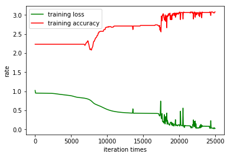

```
The roc_auc_score is 1.0
The accuracy is 1.0
              precision    recall  f1-score   support

      class0       1.00      1.00      1.00        55
      class1       1.00      1.00      1.00       145

    accuracy                           1.00       200
   macro avg       1.00      1.00      1.00       200
weighted avg       1.00      1.00      1.00       200
```

```python
X, label, test, canvs = load_data()

layers = [3,6,9,9,6,1]
epoch = 25000
Loss, accuracy, Y_pred = model_caculate(X, label, X, label, layers, learning_rate=0.01, epoch= epoch)


#开始画图
x = np.linspace(0, 25000, 500)
plt.plot(x, np.array(Loss)/(max(Loss) - min(Loss)), color='green', label='training loss')
plt.plot(x, np.array(accuracy)/(max(accuracy) - min(accuracy)), color='red', label='training accuracy')
# 显示图例
plt.legend()
plt.xlabel('iteration times')
plt.ylabel('rate')
plt.show()
evaluate_detial(label.T, Y_pred.T)
```

### 实现标准BP算法（也就是Mini-batch = 1，这样的话在python下使用for循环喂数据会非常慢）

```python
def model_std(X, Y, X_test, Y_test, layers, learning_rate = 0.01, epoch = 1000, interval = 50):
    parameters = initial(layers)
    Loss = []
    Acc = []
    accuracy = None
    loss = None
    Y_pred = None
    start = time.time()
    for i in range(epoch):
        for j in range(0, X.shape[1]):
            cache = L_layers_propagation(parameters, X[:, j].reshape(3, -1))
            cache = L_back_propagation(cache, parameters, Y[:, j].reshape(1, -1))
            parameters = update_parameters(cache, parameters, learning_rate)
        if i % interval == 0:
            Y_pred = predict(parameters, X_test, draw = False)

            loss = lossFunc(Y_test, Y_pred)[0,0]
            Loss.append(loss)
            accuracy = evaluate(Y_test, Y_pred)
            Acc.append(accuracy)
            if i % (interval * 20) == 0:
                now = time.time()
                print("Stander Dense Net:~$  {}th epoch,  accuracy: {},   loss:{},  time:{}".format(i, accuracy, loss, now - start))
                start = time.time()
    return Loss, Acc, Y_pred
```

```
Stander Dense Net:~$  0th epoch,  accuracy: 0.65,   loss:35.0,  time:0.01568889617919922
Stander Dense Net:~$  1000th epoch,  accuracy: 0.65,   loss:35.0,  time:15.484315395355225
Stander Dense Net:~$  2000th epoch,  accuracy: 0.65,   loss:35.0,  time:15.486449480056763
Stander Dense Net:~$  3000th epoch,  accuracy: 0.65,   loss:35.0,  time:15.427065372467041
Stander Dense Net:~$  4000th epoch,  accuracy: 0.65,   loss:35.0,  time:15.558948755264282
Stander Dense Net:~$  5000th epoch,  accuracy: 0.65,   loss:35.0,  time:15.490538835525513
Stander Dense Net:~$  6000th epoch,  accuracy: 0.65,   loss:35.0,  time:15.39825701713562
Stander Dense Net:~$  7000th epoch,  accuracy: 0.65,   loss:35.0,  time:15.501217126846313
Stander Dense Net:~$  8000th epoch,  accuracy: 0.71,   loss:29.0,  time:15.471642017364502
Stander Dense Net:~$  9000th epoch,  accuracy: 0.735,   loss:26.5,  time:15.505938291549683
Stander Dense Net:~$  10000th epoch,  accuracy: 0.755,   loss:24.5,  time:15.494549751281738
Stander Dense Net:~$  11000th epoch,  accuracy: 0.75,   loss:25.0,  time:15.523139953613281
Stander Dense Net:~$  12000th epoch,  accuracy: 0.84,   loss:16.0,  time:15.45572280883789
Stander Dense Net:~$  13000th epoch,  accuracy: 0.955,   loss:4.5,  time:15.487808227539062
Stander Dense Net:~$  14000th epoch,  accuracy: 0.975,   loss:2.5,  time:15.503306865692139
Stander Dense Net:~$  15000th epoch,  accuracy: 0.99,   loss:1.0,  time:15.520313262939453
Stander Dense Net:~$  16000th epoch,  accuracy: 0.99,   loss:1.0,  time:15.438772201538086
Stander Dense Net:~$  17000th epoch,  accuracy: 0.99,   loss:1.0,  time:15.322555780410767
Stander Dense Net:~$  18000th epoch,  accuracy: 0.99,   loss:1.0,  time:15.307707071304321
Stander Dense Net:~$  19000th epoch,  accuracy: 0.99,   loss:1.0,  time:15.418060541152954
Stander Dense Net:~$  20000th epoch,  accuracy: 0.99,   loss:1.0,  time:15.364104270935059
Stander Dense Net:~$  21000th epoch,  accuracy: 0.995,   loss:0.5,  time:15.45631742477417
Stander Dense Net:~$  22000th epoch,  accuracy: 0.995,   loss:0.5,  time:15.565281867980957
Stander Dense Net:~$  23000th epoch,  accuracy: 0.995,   loss:0.5,  time:15.429940462112427
Stander Dense Net:~$  24000th epoch,  accuracy: 0.995,   loss:0.5,  time:15.388113737106323
Stander Dense Net:~$  25000th epoch,  accuracy: 0.995,   loss:0.5,  time:15.410844564437866
Stander Dense Net:~$  26000th epoch,  accuracy: 0.995,   loss:0.5,  time:15.511346340179443
Stander Dense Net:~$  27000th epoch,  accuracy: 0.995,   loss:0.5,  time:15.331661939620972
Stander Dense Net:~$  28000th epoch,  accuracy: 0.995,   loss:0.5,  time:15.609029531478882
Stander Dense Net:~$  29000th epoch,  accuracy: 0.995,   loss:0.5,  time:15.470206260681152
Stander Dense Net:~$  30000th epoch,  accuracy: 0.995,   loss:0.5,  time:15.510454654693604
Stander Dense Net:~$  31000th epoch,  accuracy: 0.995,   loss:0.5,  time:15.524166107177734
Stander Dense Net:~$  32000th epoch,  accuracy: 0.995,   loss:0.5,  time:15.514365196228027
Stander Dense Net:~$  33000th epoch,  accuracy: 0.995,   loss:0.5,  time:15.420735597610474
```

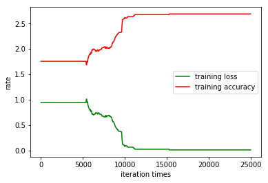

```
The roc_auc_score is 0.9961538461538462
The accuracy is 0.995
              precision    recall  f1-score   support

      class0       0.99      1.00      0.99        70
      class1       1.00      0.99      1.00       130

    accuracy                           0.99       200
   macro avg       0.99      1.00      0.99       200
weighted avg       1.00      0.99      1.00       200
```

[figure not shown]

```python
X, label, test, canvs = load_data()
layers = [3,6,9,9,6,1]
epoch = 33300
Loss,accuracy, Y_pred = model_std(X, label, X, label, layers, learning_rate=0.01, epoch= epoch)

#开始画图
x = np.linspace(0, 25000, epoch/50)
plt.plot(x, np.array(Loss)/(max(Loss) - min(Loss)), color='green', label='training loss')
plt.plot(x, np.array(accuracy)/(max(accuracy) - min(accuracy)), color='red', label='training accuracy')
# 显示图例
plt.legend()
plt.xlabel('iteration times')
plt.ylabel('rate')
plt.show()

evaluate_detial(label.T, Y_pred.T)
```

## 动态可视化训练过程

```python
def main(epoch= 50000, detial=True, draw=False):
    X, label, test, canvs = load_data()
    layers = [3,6,9,9,6,1]
    if draw == True:
        for im in model(X, label, test, canvs, layers, learning_rate=0.01, epoch= epoch, detial = detial, draw = True):
            plt.clf()
            display.clear_output(wait=True)
            plt.contourf(canvs[0] ,canvs[1], im, cmap=plt.cm.Spectral)
            plt.scatter(X[0,:], X[1,:],c=label[0,:])
            plt.pause(0.01)
    else:
        parameters = model(X, label, test, canvs, layers, learning_rate=0.01, epoch= 30000, detial = detial, draw = draw)
        Plot(X, label, parameters)
```

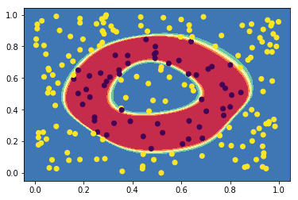

```
accuracy is 0.98
```

```python
main(epoch= 20000, detial=False, draw=True)
```

# 西瓜数据集3.0$\alpha$上的分类

### 导入数据

```python
import numpy as np
import copy
def load():
    data = np.array([[0.697, 0.460, 1],
    [0.774, 0.376, 1],
    [0.634, 0.264, 1],
    [0.608, 0.318, 1],
    [0.556, 0.215, 1],
    [0.403, 0.237, 1],
    [0.481, 0.149, 1],
    [0.437, 0.211, 1],
    [0.666, 0.091, 0],
    [0.243, 0.267, 0],
    [0.245, 0.057, 0],
    [0.343, 0.099, 0],
    [0.639, 0.161, 0],
    [0.657, 0.198, 0],
    [0.360, 0.370, 0],
    [0.593, 0.042, 0],
    [0.719, 0.103, 0]])

    Y = copy.deepcopy(data[:, 2].reshape(-1, 1).T)
    data[:, 2] = 1
    X = copy.deepcopy(data.T)

    X_test = copy.deepcopy(np.c_[X[:, 0:2],X[:, -3:-1]])
    Y_test = copy.deepcopy(np.c_[Y[:, 0:2],Y[:, -3:-1]])

    X_train = copy.deepcopy(X[:, 2:-2])
    Y_train = copy.deepcopy(Y[:, 2:-2])

    return X_train, Y_train, X_test, Y_test, X, Y
X_train, Y_train, X_test, Y_test, X, Y = load()
print(Y.shape)
```

```
(1, 17)
```